# Employee Dimission Probability Prediction Model

Ningkai Zheng

# 1 Introduction

For the company’s *outstanding employees and experienced employees*, we need to build a prediction model to forecast their probability of leaving.

## 1.1 Load packages

```r
library(xray)
library(ggthemes)
library(tidyverse)
library(caret)
library(pROC)
library(DT)
```

## 1.2 Load data

```r
hr = read.csv("HR_comma_sep.csv")
summary(hr)
```

```
##  satisfaction_level last_evaluation  number_project  average_montly_hours
##  Min.   :0.0900     Min.   :0.3600   Min.   :2.000   Min.   : 96.0
##  1st Qu.:0.4400     1st Qu.:0.5600   1st Qu.:3.000   1st Qu.:156.0
##  Median :0.6400     Median :0.7200   Median :4.000   Median :200.0
##  Mean   :0.6128     Mean   :0.7161   Mean   :3.803   Mean   :201.1
##  3rd Qu.:0.8200     3rd Qu.:0.8700   3rd Qu.:5.000   3rd Qu.:245.0
##  Max.   :1.0000     Max.   :1.0000   Max.   :7.000   Max.   :310.0
##  time_spend_company Work_accident         left        promotion_last_5years
##  Min.   : 2.000     Min.   :0.0000   Min.   :0.0000   Min.   :0.00000
##  1st Qu.: 3.000     1st Qu.:0.0000   1st Qu.:0.0000   1st Qu.:0.00000
##  Median : 3.000     Median :0.0000   Median :0.0000   Median :0.00000
##  Mean   : 3.498     Mean   :0.1446   Mean   :0.2381   Mean   :0.02127
##  3rd Qu.: 4.000     3rd Qu.:0.0000   3rd Qu.:0.0000   3rd Qu.:0.00000
##  Max.   :10.000     Max.   :1.0000   Max.   :1.0000   Max.   :1.00000
##     sales              salary
##  Length:14999       Length:14999
##  Class :character   Class :character
##  Mode  :character   Mode  :character
##
##
##
```

## 1.3 Find problematic variables

```r
anomalies(hr)
```

```
## $variables
##                 Variable     q qNA pNA qZero  pZero qBlank pBlank qInf pInf
## 1  promotion_last_5years 14999   0   - 14680 97.87%      0      -    0    -
## 2          Work_accident 14999   0   - 12830 85.54%      0      -    0    -
## 3                   left 14999   0   - 11428 76.19%      0      -    0    -
## 4                 salary 14999   0   -     0      -      0      -    0    -
## 5         number_project 14999   0   -     0      -      0      -    0    -
## 6     time_spend_company 14999   0   -     0      -      0      -    0    -
## 7                  sales 14999   0   -     0      -      0      -    0    -
## 8        last_evaluation 14999   0   -     0      -      0      -    0    -
## 9     satisfaction_level 14999   0   -     0      -      0      -    0    -
## 10  average_montly_hours 14999   0   -     0      -      0      -    0    -
##    qDistinct      type anomalous_percent
## 1          2   Integer            97.87%
## 2          2   Integer            85.54%
```

[output cut: 16 more lines]

Both variables containing a high proportion of zero values are reasonable.

# 2 Descriptive analysis

Let’s have an overview of the impact of all the factors.

## 2.1 Satisfaction level

Employees who have left are less satisfied with the company.

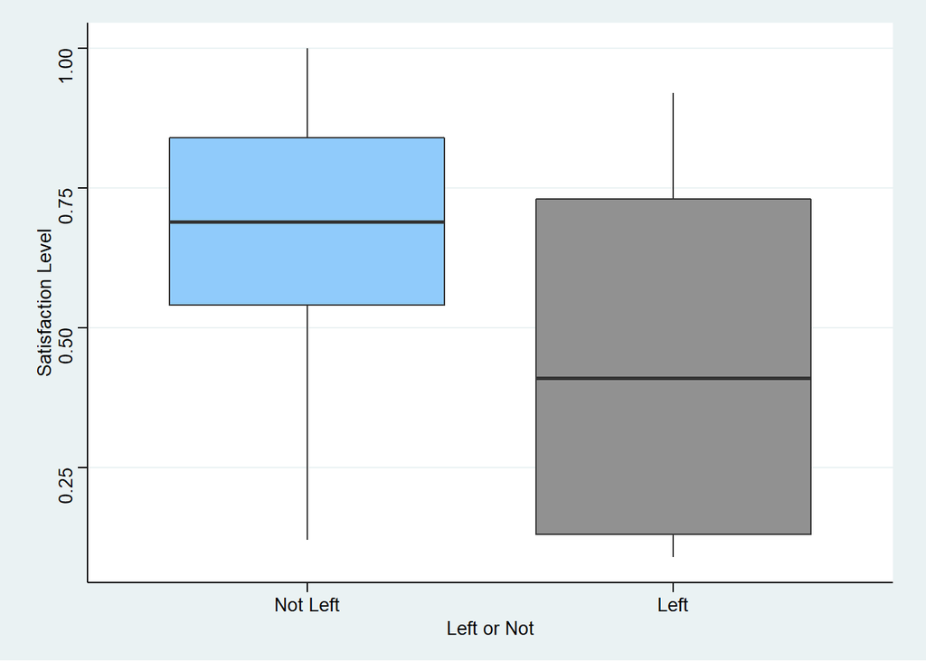

```r
hr %>%
  ggplot(aes(factor(left, labels=c("Not Left","Left")),
             satisfaction_level, fill=as.factor(left))) +
  geom_boxplot() +
  labs(x="Left or Not", y="Satisfaction Level") +
  theme_stata() +
  theme(legend.position = "none") +
  scale_fill_manual(values=c("#90CBFB","#919191"))
```

## 2.2 Evaluation

Performance evaluations are higher for employees who have left compared to those who are still employed. This may be because employees with high performance evaluations are also highly competent and they have the ability to find better jobs.

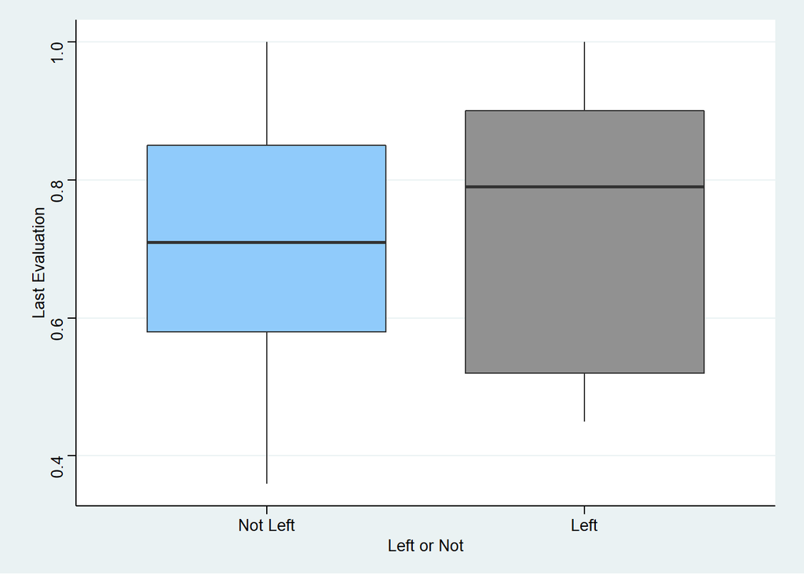

```r
hr %>%
  ggplot(aes(factor(left, labels=c("Not Left","Left")),
                    last_evaluation, fill=as.factor(left))) +
  geom_boxplot() +
  labs(x="Left or Not", y="Last Evaluation") +
  theme_stata() +
  theme(legend.position = "none") +
  scale_fill_manual(values=c("#90CBFB","#919191"))
```

## 2.3 Average monthly working hours

The average monthly working hours of employees who have left the company are longer.

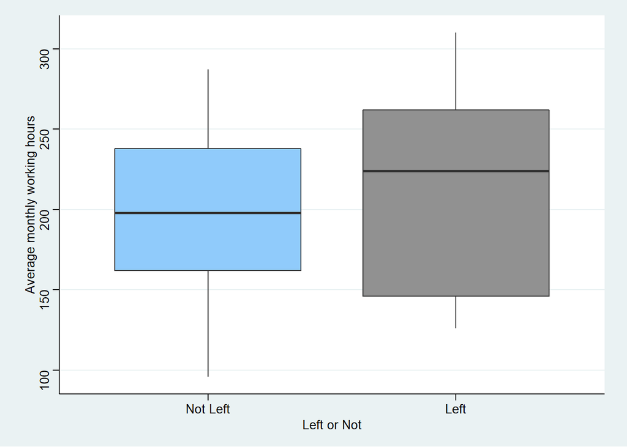

```r
hr %>%
  ggplot(aes(factor(left, labels=c("Not Left","Left")),
             average_montly_hours, fill=as.factor(left))) +
  geom_boxplot() +
  labs(x="Left or Not", y="Average monthly working hours") +
  theme_stata() +
  theme(legend.position = "none") +
  scale_fill_manual(values=c("#90CBFB","#919191"))
```

## 2.4 Years of work

The majority of employees who have left the company have around four years of work.

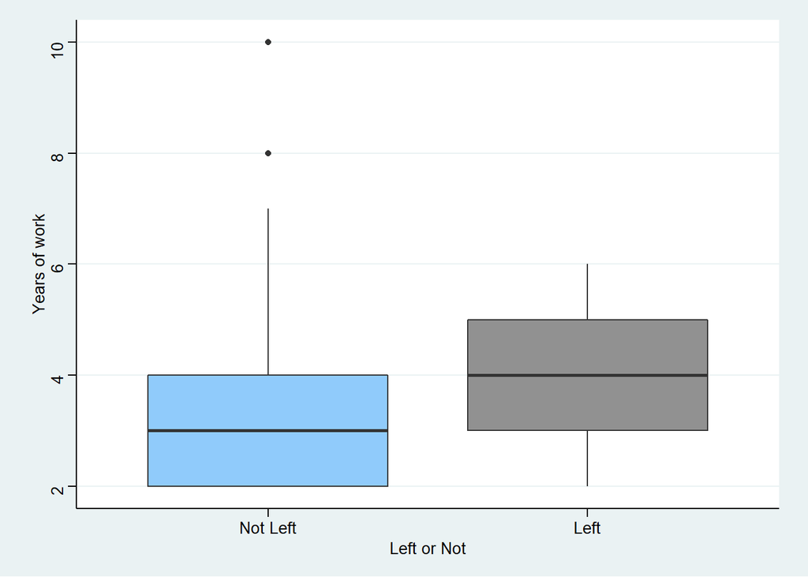

```r
hr %>%
  ggplot(aes(factor(left, labels=c("Not Left","Left")),
             time_spend_company, fill=as.factor(left))) +
  geom_boxplot() +
  labs(x="Left or Not", y="Years of work") +
  theme_stata() +
  theme(legend.position = "none") +
  scale_fill_manual(values=c("#90CBFB","#919191"))
```

## 2.5 Number of projects

A greater proportion of employees leave for those with fewer and more projects.

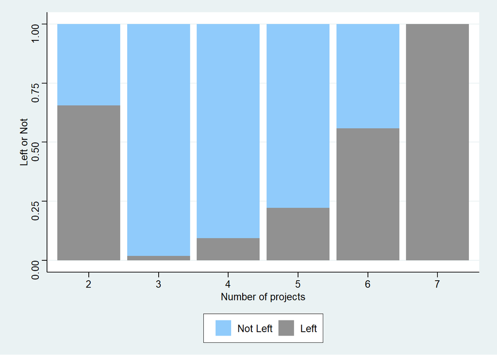

```r
hr %>%
  ggplot(aes(as.factor(number_project), fill=as.factor(left))) +
  geom_bar(position="fill") +
  labs(x="Number of projects", y="Left or Not") +
  theme_stata() +
  theme(legend.title = element_blank()) +
  scale_fill_manual(values=c("#90CBFB","#919191"),labels=c("Not Left","Left"))
```

## 2.6 Promotion within five years

The turnover rate is higher among employees who have not been promoted within five years.

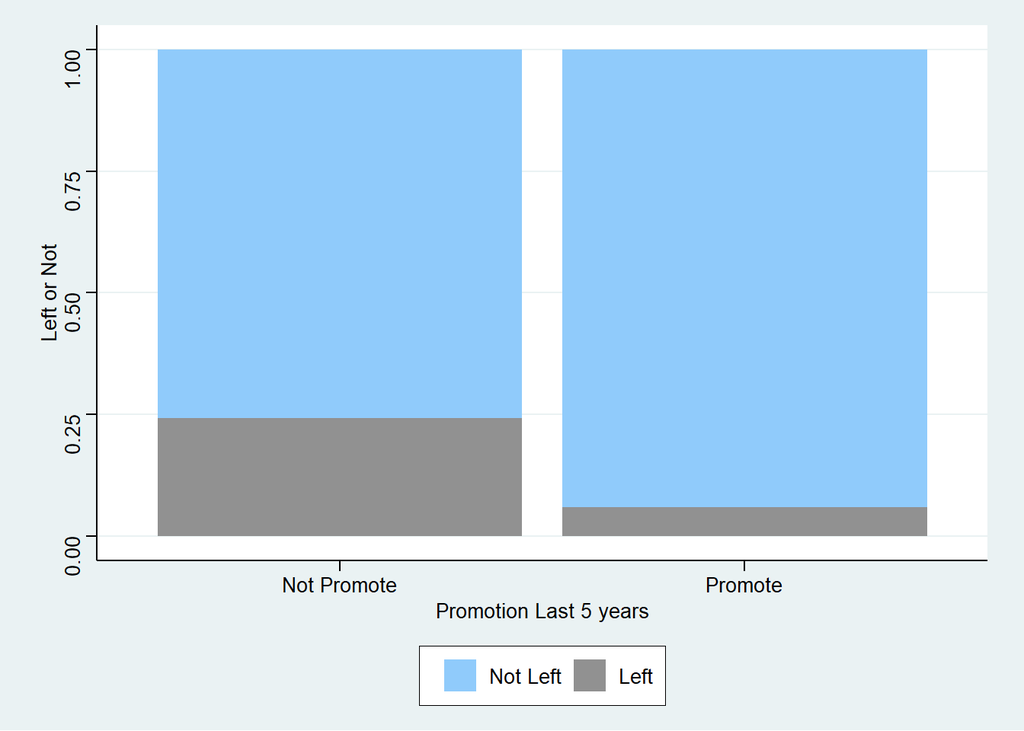

```r
hr %>%
  ggplot(aes(factor(promotion_last_5years,labels=c("Not Promote","Promote")),
             fill=as.factor(left))) +
  geom_bar(position="fill") +
  labs(x="Promotion Last 5 years", y="Left or Not") +
  theme_stata() +
  theme(legend.title = element_blank()) +
  scale_fill_manual(values=c("#90CBFB","#919191"),labels=c("Not Left","Left"))
```

## 2.7 Salary level

The lower the salary level, the higher the turnover rate among employees.

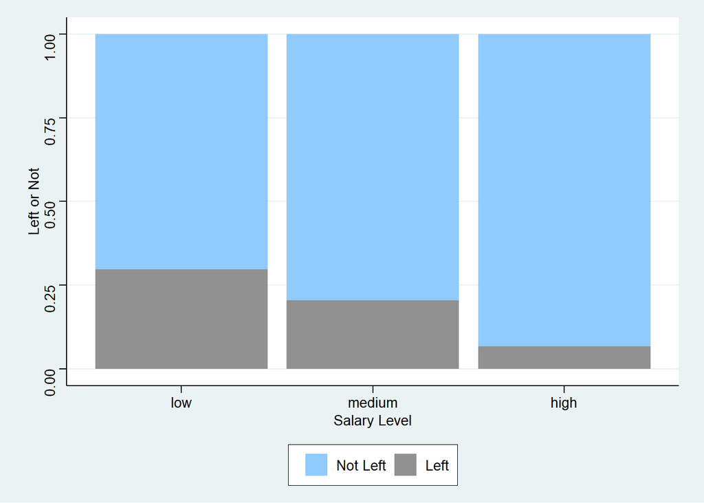

```r
hr %>%
  ggplot(aes(factor(salary,levels=c("low","medium","high")),
             fill=as.factor(left))) +
  geom_bar(position="fill") +
  labs(x="Salary Level", y="Left or Not") +
  theme_stata() +
  theme(legend.title = element_blank()) +
  scale_fill_manual(values=c("#90CBFB","#919191"),labels=c("Not Left","Left"))
```

# 3 Modelling

Select good and experienced employees.

```r
hr_model=hr %>%
  filter(last_evaluation>=0.7 | time_spend_company>=4 | number_project>=6)
```

Set 5-fold cross-validation.

```r
train_control=trainControl(method="cv",number=5)
```

```r
set.seed(1234)
```

Extract 70% of the data as training data and store the row index in “index”.

```r
index=createDataPartition(hr_model$left, p=0.7, list=F)
```

Extract training data and test data.

```r
train_data=hr_model[index,]
test_data=hr_model[-index,]
```

## 3.1 Regression tree

```r
train_data$left=as.factor(train_data$left)
```

Build the model.

```r
fit1 = train(left~., data=train_data, trControl=train_control, method="rpart")
```

Predictions using the model.

```r
fore1=predict(fit1, test_data[-7])
```

Confusion matrix:

```r
table(fore1,test_data$left)
```

```
##
## fore1    0    1
##     0 2273   97
##     1   52  509
```

Precision=509/(509+52)=90.73% Recall=509/(509+97)=83.99%

## 3.2 Naive Bayes

```r
fit2=train(left~., data=train_data, trControl=train_control, method="nb")
```

```r
fore2=predict(fit2, test_data[-7])
```

```r
table(fore2, test_data$left)
```

```
##
## fore2    0    1
##     0 2301  206
##     1   24  400
```

Precision=400/(400+24)=94.34% Recall=400/(400+206)=66.01%

## 3.3 Logistic regression

```r
fit3=step(glm(left ~ 1, family=binomial, train_data), direction="forward",
          scope=~ satisfaction_level + last_evaluation + number_project +
            average_montly_hours + time_spend_company + Work_accident +
            promotion_last_5years + sales + salary)
```

```
## Start:  AIC=6957.42
## left ~ 1
##
##                         Df Deviance    AIC
## + average_montly_hours   1   5269.7 5273.7
## + number_project         1   5297.5 5301.5
## + last_evaluation        1   6351.3 6355.3
## + satisfaction_level     1   6393.7 6397.7
## + time_spend_company     1   6692.2 6696.2
## + Work_accident          1   6753.9 6757.9
## + salary                 2   6751.9 6757.9
## + promotion_last_5years  1   6900.3 6904.3
## + sales                  9   6913.8 6933.8
## <none>                       6955.4 6957.4
##
## Step:  AIC=5273.71
## left ~ average_montly_hours
##
##                         Df Deviance    AIC
## + number_project         1   4349.4 4355.4
## + last_evaluation        1   4816.0 4822.0
## + time_spend_company     1   5001.9 5007.9
## + satisfaction_level     1   5078.1 5084.1
## + Work_accident          1   5109.8 5115.8
## + salary                 2   5116.6 5124.6
## + promotion_last_5years  1   5217.9 5223.9
## + sales                  9   5242.5 5264.5
## <none>                       5269.7 5273.7
##
## Step:  AIC=4355.36
## left ~ average_montly_hours + number_project
##
##                         Df Deviance    AIC
## + last_evaluation        1   3878.3 3886.3
## + time_spend_company     1   4122.3 4130.3
## + salary                 2   4215.3 4225.3
## + Work_accident          1   4229.5 4237.5
## + promotion_last_5years  1   4307.0 4315.0
## + sales                  9   4316.4 4340.4
## + satisfaction_level     1   4347.1 4355.1
```

[output cut: 54 more lines]

```
## <none>                    3327.4 3345.4
##
## Step:  AIC=3338.44
## left ~ average_montly_hours + number_project + last_evaluation +
##     time_spend_company + salary + Work_accident + promotion_last_5years +
##     sales
##
##                      Df Deviance    AIC
## + satisfaction_level  1   3298.4 3336.4
## <none>                    3302.4 3338.4
##
## Step:  AIC=3336.42
## left ~ average_montly_hours + number_project + last_evaluation +
##     time_spend_company + salary + Work_accident + promotion_last_5years +
##     sales + satisfaction_level
```

```r
summary(fit3)
```

```
##
## Call:
## glm(formula = left ~ average_montly_hours + number_project +
##     last_evaluation + time_spend_company + salary + Work_accident +
##     promotion_last_5years + sales + satisfaction_level, family = binomial,
##     data = train_data)
##
## Deviance Residuals:
##     Min       1Q   Median       3Q      Max
## -2.7389  -0.3483  -0.1451  -0.0346   4.0324
##
## Coefficients:
##                         Estimate Std. Error z value Pr(>|z|)
## (Intercept)           -22.111360   0.694603 -31.833  < 2e-16 ***
## average_montly_hours    0.026406   0.001278  20.658  < 2e-16 ***
## number_project          1.083458   0.051833  20.903  < 2e-16 ***
## last_evaluation         7.471089   0.407032  18.355  < 2e-16 ***
## time_spend_company      0.505849   0.028188  17.945  < 2e-16 ***
## salarylow               2.139516   0.262579   8.148 3.70e-16 ***
## salarymedium            1.545990   0.263499   5.867 4.43e-09 ***
## Work_accident          -1.486167   0.174762  -8.504  < 2e-16 ***
## promotion_last_5years  -2.426548   0.582571  -4.165 3.11e-05 ***
## saleshr                 0.474509   0.275127   1.725   0.0846 .
## salesIT                -0.161281   0.244759  -0.659   0.5099
## salesmanagement        -0.521102   0.315786  -1.650   0.0989 .
## salesmarketing         -0.215291   0.270944  -0.795   0.4268
## salesproduct_mng       -0.375811   0.270234  -1.391   0.1643
## salesRandD             -0.376461   0.274911  -1.369   0.1709
## salessales             -0.039626   0.208260  -0.190   0.8491
## salessupport            0.147136   0.221405   0.665   0.5063
## salestechnical          0.182528   0.212411   0.859   0.3902
## satisfaction_level     -0.358428   0.178407  -2.009   0.0445 *
## ---
## Signif. codes:  0 '***' 0.001 '**' 0.01 '*' 0.05 '.' 0.1 ' ' 1
##
## (Dispersion parameter for binomial family taken to be 1)
##
##     Null deviance: 6955.4  on 6840  degrees of freedom
## Residual deviance: 3298.4  on 6822  degrees of freedom
## AIC: 3336.4
##
## Number of Fisher Scoring iterations: 7
```

```r
fore3=predict(fit3, test_data[-7], type="response")
```

```r
table(test_data$left, fore3>=0.5)
```

```
##
##     FALSE TRUE
##   0  2216  109
##   1   167  439
```

Precision=439/(439+109)=80.11% Recall=439/(439+167)=72.44%

# 4 Model evaluation

```r
roc_fit1=roc(test_data$left, as.numeric(as.character(fore1)))
```

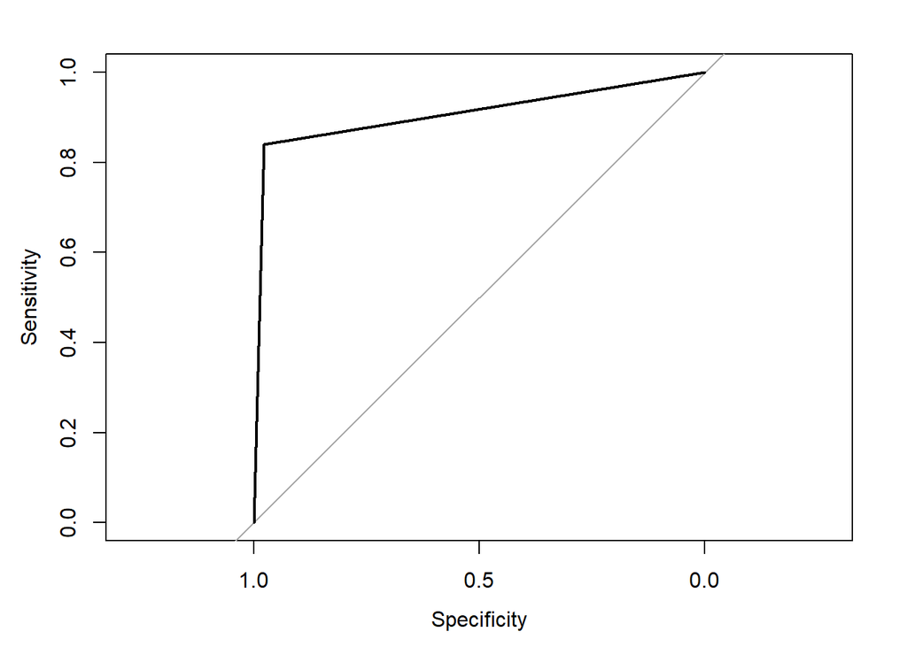

```r
plot(roc_fit1)
```

```r
auc(roc_fit1)
```

```
## Area under the curve: 0.9088
```

```r
roc_fit2=roc(test_data$left, as.numeric(as.character(fore2)))
```

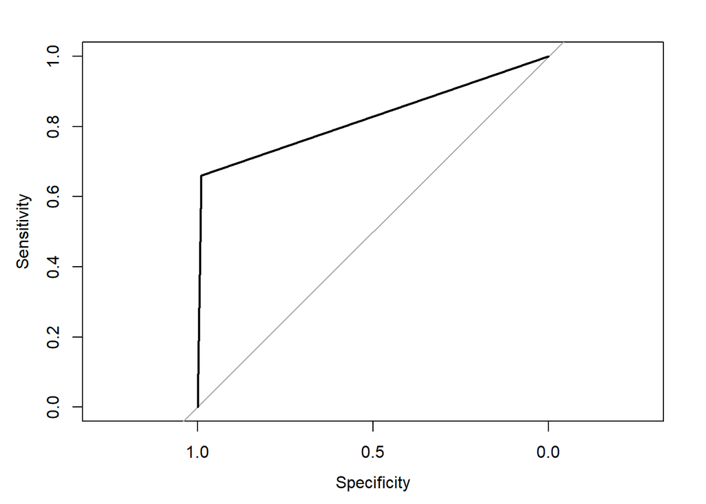

```r
plot(roc_fit2)
```

```r
auc(roc_fit2)
```

```
## Area under the curve: 0.8249
```

```r
roc_fit3=roc(test_data$left, fore3)
```

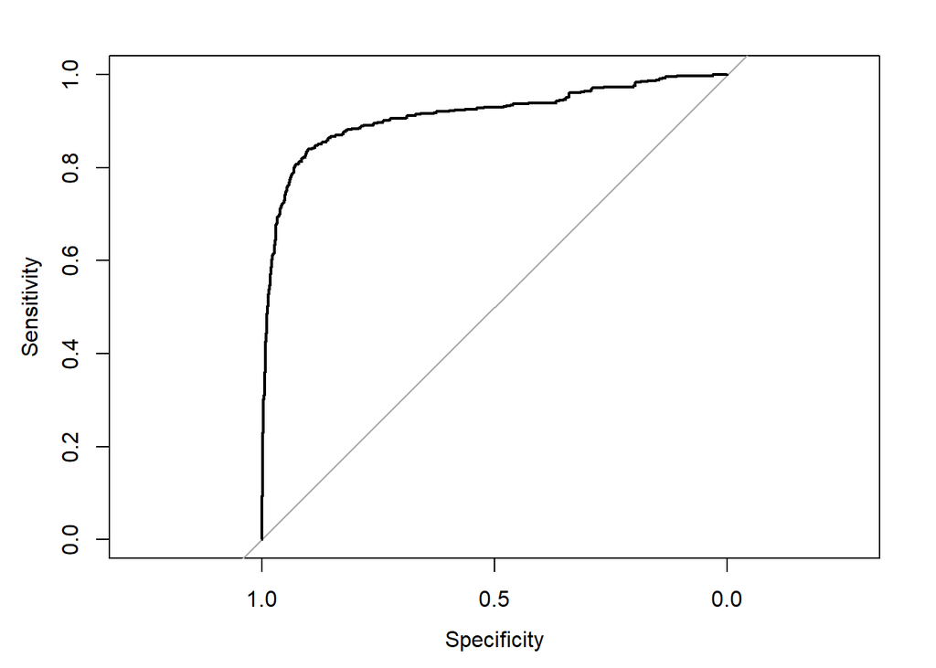

```r
plot(roc_fit3)
```

```r
auc(roc_fit3)
```

```
## Area under the curve: 0.9128
```

The logistic regression model has the largest auc value, suggesting that it’s the best model.

# 5 Application

We can use the models to predict the probability of leaving the company for *outstanding and experienced employees*.

## 5.1 The best model: logistic regression model

```r
pred=as.numeric((fore3>=0.5))
data=cbind(round(fore3,3),pred)
colnames(data)=c("probability","prediction")
datatable(data)
```

|  | probability | prediction |
| --- | --- | --- |
| 2 | 0.938 | 1 |
| 4 | 0.68 | 1 |
| 6 | 0.731 | 1 |
| 7 | 0.929 | 1 |
| 8 | 0.402 | 0 |
| 10 | 0.774 | 1 |
| 12 | 0.974 | 1 |
| 13 | 0.707 | 1 |
| 19 | 0.821 | 1 |
| 21 | 0.933 | 1 |

[output cut: 2921 more lines]

## 5.2 The regression tree model

```r
pred1=predict(fit1, test_data[-7], type="prob")
data1=cbind(round(pred1,3),fore1)
colnames(data1)=c("Prob1","Prob2","prediction")
datatable(data1)
```

|  | Prob1 | Prob2 | prediction |
| --- | --- | --- | --- |
| 2 | 0 | 1 | 1 |
| 4 | 0 | 1 | 1 |
| 6 | 0.158 | 0.842 | 1 |
| 7 | 0 | 1 | 1 |
| 8 | 0.158 | 0.842 | 1 |
| 10 | 0.158 | 0.842 | 1 |
| 12 | 0 | 1 | 1 |
| 13 | 0.158 | 0.842 | 1 |
| 19 | 0.158 | 0.842 | 1 |
| 21 | 0 | 1 | 1 |

[output cut: 2921 more lines]